# Chapter 4

```r
require(data.table)
require(ggplot2)
theme_set(
    theme_bw(base_size = 14, base_family = "Lato") +
    theme(panel.grid = element_blank(), panel.border = element_blank())
)
```

Okay! We’re going back to our bike path dataset here. I live in Montreal, and I was curious about whether we’re more of a commuter city or a biking-for-fun city – do people bike more on weekends, or on weekdays?

# 4.1 Adding a ‘weekday’ column to our dataframe

First, we need to load up the data. We’ve done this before.

```r
bikes <- fread("../data/bikes.csv", sep = ";", encoding = "Latin-1", fill = TRUE, index = "Date")
bikes[, Date := as.Date(Date, "%d/%m/%Y")]

## let's look at the dataset again
head(bikes)
```

```
#>          Date Berri 1 Brébeuf (données non disponibles)
#> 1: 2012-01-01      35                                NA
#> 2: 2012-01-02      83                                NA
#> 3: 2012-01-03     135                                NA
#> 4: 2012-01-04     144                                NA
#> 5: 2012-01-05     197                                NA
#> 6: 2012-01-06     146                                NA
#>    Côte-Sainte-Catherine Maisonneuve 1 Maisonneuve 2 du Parc Pierre-Dupuy
#> 1:                     0            38            51      26           10
#> 2:                     1            68           153      53            6
#> 3:                     2           104           248      89            3
#> 4:                     1           116           318     111            8
#> 5:                     2           124           330      97           13
#> 6:                     0            98           244      86            4
#>    Rachel1 St-Urbain (données non disponibles)
#> 1:      16                                  NA
#> 2:      43                                  NA
#> 3:      58                                  NA
#> 4:      61                                  NA
#> 5:      95                                  NA
#> 6:      75                                  NA
```

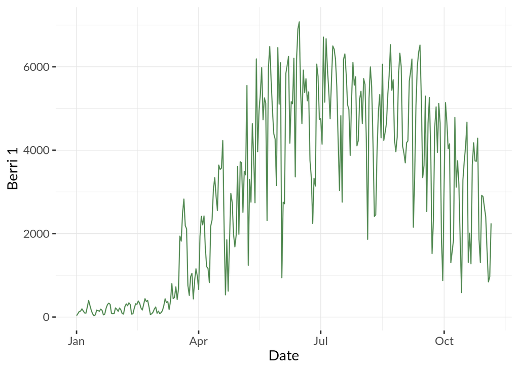

```r
ggplot(bikes, aes(Date, `Berri 1`)) +
    geom_line(color = "palegreen4") +
    theme(panel.grid = element_line(size = 0.3, color = "gray90"))
```

Next up, we’re just going to look at the Berri bike path. Berri is a street in Montreal, with a pretty important bike path. I use it mostly on my way to the library now, but I used to take it to work sometimes when I worked in Old Montreal.

So we’re going to create a dataframe with just the Berri bikepath in it.

```r
berri_bikes <- bikes[, .(Date, `Berri 1`)]
berri_bikes[1:5]
```

```
#>          Date Berri 1
#> 1: 2012-01-01      35
#> 2: 2012-01-02      83
#> 3: 2012-01-03     135
#> 4: 2012-01-04     144
#> 5: 2012-01-05     197
```

Next, we need to add a `weekday` column. There are two ways to perform the task. Firstly, we can use function `base::weekdays()` which gives us names of days of the week. Or we can make use of `data.table` built-in utility function `wday()`. I used both.

```r
berri_bikes[, weekday_int := wday(Date)]
berri_bikes[, weekday_str := weekdays(Date)]
print(berri_bikes)
```

```
#>            Date Berri 1 weekday_int weekday_str
#>   1: 2012-01-01      35           1      Sunday
#>   2: 2012-01-02      83           2      Monday
#>   3: 2012-01-03     135           3     Tuesday
#>   4: 2012-01-04     144           4   Wednesday
#>   5: 2012-01-05     197           5    Thursday
#>  ---
#> 306: 2012-11-01    2405           5    Thursday
#> 307: 2012-11-02    1582           6      Friday
#> 308: 2012-11-03     844           7    Saturday
#> 309: 2012-11-04     966           1      Sunday
#> 310: 2012-11-05    2247           2      Monday
```

# 4.2 Adding up the cyclists by weekday

This turns out to be really easy!

Performing aggregation is one of distinctive feature of `data.table`, it is similar to SQL `GROUP BY`. You can check out the [documentation](https://rdatatable.gitlab.io/data.table/articles/datatable-intro.html#a-grouping-using-by) to learn more.

In this case, `berri_bikes[, .(total_berri = sum('Berri 1')), by = .(weekday_str)]` means “Group the rows by weekday and then add up all the values with the same weekday”.

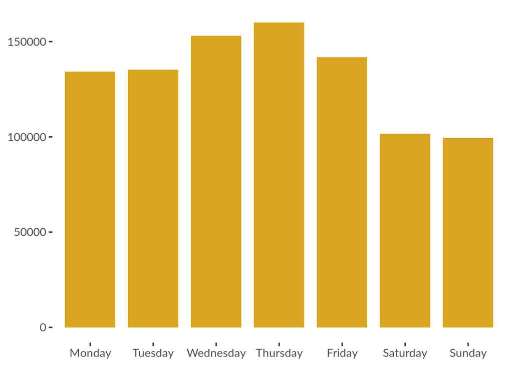

```r
weekday_counts <- berri_bikes[, .(total_berri = sum(`Berri 1`)), by = .(weekday_str)]

## we want an ordered vector of `weekday` which is really helpful for visualising
weekday_counts[, weekday_str := factor(weekday_str,
                                       levels = c("Monday", "Tuesday", "Wednesday", "Thursday",
                                                  "Friday", "Saturday", "Sunday"),
                                       ordered = TRUE)]

ggplot(weekday_counts, aes(weekday_str, total_berri)) +
    geom_col(fill = "goldenrod", width = 0.8) +
    labs(x = NULL, y = NULL)
```

So it looks like Montrealers are commuter cyclists – they bike much more during the week. Neat!

# 4.3 Putting it all together

Let’s put all that together, to prove how easy it is.

If you want to play around, try changing `sum` to `max`, `median`, or any other function you like.

```r
bikes <- fread("../data/bikes.csv", sep = ";", encoding = "Latin-1", fill = TRUE, index = "Date")
bikes[, Date := as.Date(Date, "%d/%m/%Y")]
berri_bikes[, weekday_str := weekdays(Date)]
weekday_counts <- berri_bikes[, .(total_berri = sum(`Berri 1`)), by = .(weekday_str)]
weekday_counts[, weekday_str := factor(weekday_str,
                                       levels = c("Monday", "Tuesday", "Wednesday", "Thursday",
                                                  "Friday", "Saturday", "Sunday"),
                                       ordered = TRUE)]
ggplot(weekday_counts, aes(weekday_str, total_berri)) +
    geom_col(fill = "goldenrod", width = 0.8) +
    labs(x = NULL, y = NULL)
```

[output not shown]